Capstone ML : Scotty Time Series Forecasting Faris Dzikrur Rahman 2019-09-24

```r
library(tidyverse)
library(ggplot2)
library(dplyr)
library(forecast)
library(purrr)
library(yardstick)
library(lubridate)
library(recipes)
library(magrittr)
library(plotly)
library(MLmetrics)
```

# Data Preparation

```r
scotty <- read_csv("drive-download-20190915T022902Z-001/scotty-ts-auto/data/data-train.csv")
data_submission <- read_csv("drive-download-20190915T022902Z-001/scotty-ts-auto/data/data-submission.csv")
str(scotty)
```

```
## Classes 'spec_tbl_df', 'tbl_df', 'tbl' and 'data.frame': 90113 obs. of  16 variables:
##  $ id                : chr  "59d005e1ffcfa261708ce9cd" "59d0066affcfa261708ceb11" "59d006a1ffcfa261708ceba4" "59d006d8cb564761a8fe5efd" ...
##  $ trip_id           : chr  "59d005e9cb564761a8fe5d3e" NA "59d006c131e39c618969343d" "59d007193d32b861760d4a77" ...
##  $ driver_id         : chr  "59a892c5568be44b2734f276" NA "599dc0dfa5b4fd5471ad8453" "59a5856573d56e7103b5d51d" ...
##  $ rider_id          : chr  "59ad2d6efba75a581666b506" "59cd704bcf482f6ce2fadfdb" "59bd62cc7e3c3b663924ba86" "59c17cd1f6da2d274e16d0a7" ...
##  $ start_time        : POSIXct, format: "2017-10-01 00:00:17" "2017-10-01 00:02:34" ...
##  $ src_lat           : num  41.1 41.1 41 41.1 41.1 ...
##  $ src_lon           : num  29 29 29 29 29 ...
##  $ src_area          : chr  "sxk9" "sxk9" "sxk9" "sxk9" ...
##  $ src_sub_area      : chr  "sxk9s" "sxk9e" "sxk9s" "sxk9e" ...
##  $ dest_lat          : num  41.1 41.1 41 41.1 41 ...
##  $ dest_lon          : num  29 29 29 29 29.1 ...
##  $ dest_area         : chr  "sxk9" "sxk9" "sxk9" "sxk9" ...
##  $ dest_sub_area     : chr  "sxk9u" "sxk9e" "sxk9e" "sxk9e" ...
##  $ distance          : num  5.38 1.13 4.17 3.36 11.69 ...
##  $ status            : chr  "confirmed" "nodrivers" "confirmed" "confirmed" ...
##  $ confirmed_time_sec: num  8 0 32 65 0 27 32 30 0 24 ...
##  - attr(*, "spec")=
##   .. cols(
##   ..   id = col_character(),
##   ..   trip_id = col_character(),
##   ..   driver_id = col_character(),
##   ..   rider_id = col_character(),
##   ..   start_time = col_datetime(format = ""),
##   ..   src_lat = col_double(),
##   ..   src_lon = col_double(),
##   ..   src_area = col_character(),
##   ..   src_sub_area = col_character(),
##   ..   dest_lat = col_double(),
##   ..   dest_lon = col_double(),
##   ..   dest_area = col_character(),
##   ..   dest_sub_area = col_character(),
##   ..   distance = col_double(),
##   ..   status = col_character(),
##   ..   confirmed_time_sec = col_double()
##   .. )
```

From the structure / glimpse of the data above, we will use start_time (order time) column and length of the status as demand. These demand data will be aggregated each hour to become demand per hour.

Then, the hourly data will be completed, especially for the hour when there were no demand. This is done so that when we do modelling, the model will be more accurate in predicting those particular condition.

```r
# convert all data to hour
subarea_scotty <- scotty %>%
  mutate(datetime = floor_date(start_time, "hour")) %>%
  group_by(src_sub_area, datetime) %>%
  summarise(demand = length(status))
```

```r
# fill NA
scotty_fill <- subarea_scotty %>%
  complete(datetime = seq(min(subarea_scotty$datetime), max(subarea_scotty$datetime), by = "hour")) %>%
  mutate(demand = ifelse(is.na(demand), 0, demand))
```

Let’s check the data once again.

```r
head(scotty_fill)
```

```
## # A tibble: 6 x 3
## # Groups:   src_sub_area [1]
##   src_sub_area datetime            demand
##   <chr>        <dttm>               <dbl>
## 1 sxk97        2017-10-01 00:00:00      6
## 2 sxk97        2017-10-01 01:00:00      4
## 3 sxk97        2017-10-01 02:00:00      9
## 4 sxk97        2017-10-01 03:00:00      2
## 5 sxk97        2017-10-01 04:00:00      5
## 6 sxk97        2017-10-01 05:00:00      4
```

```r
tail(scotty_fill)
```

```
## # A tibble: 6 x 3
## # Groups:   src_sub_area [1]
##   src_sub_area datetime            demand
##   <chr>        <dttm>               <dbl>
## 1 sxk9s        2017-12-02 18:00:00     97
## 2 sxk9s        2017-12-02 19:00:00     54
## 3 sxk9s        2017-12-02 20:00:00     30
## 4 sxk9s        2017-12-02 21:00:00     38
## 5 sxk9s        2017-12-02 22:00:00     29
## 6 sxk9s        2017-12-02 23:00:00     41
```

Below is the demand visualization of each area.

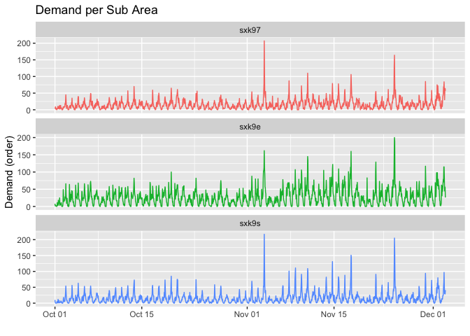

```r
ggplot(scotty_fill, aes(x = datetime, y = demand)) +
           geom_line(aes(col = src_sub_area)) +
           labs(x = "", y = "Demand (order)", title = "Demand per Sub Area") +
           facet_wrap(~ src_sub_area, scale = "free_y", ncol = 1) +
           theme(legend.position = "none")
```

After seeing the hourly, weekly, and monthly data, I decide to use hourly and weekly as a frequency in this model. This decision is taken since the data is unsufficient to predict monthly pattern, because the data only comprises 2 months.

After deciding which pattern that will be used, I then create visualization of decomposition of hourly and weekly patterm.

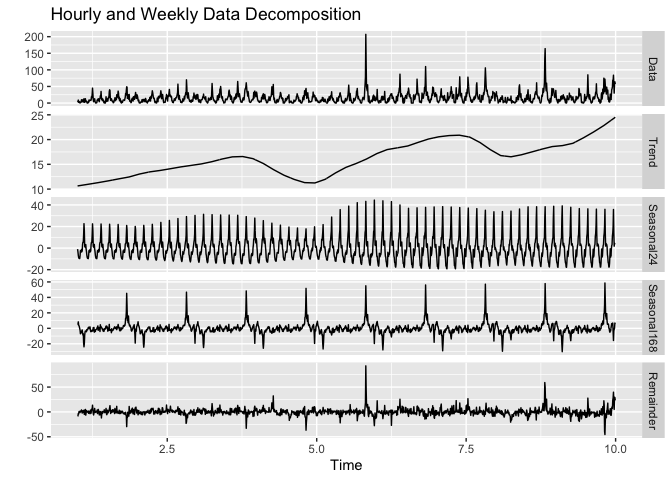

```r
dcm <- scotty_fill %>% filter(src_sub_area == "sxk97") %>% .$demand %>% msts(.,seasonal.periods = c(24,24*7))

autoplot(mstl(dcm)) + labs(title = "Hourly and Weekly Data Decomposition")
```

From the plot above, it is shown that trend is already smooth, meaning that the pattern that used is already correct.

Then, we do cross validation by dividing data into train data (to train the model) and test data (to evaluate the model). Test data is obtained from last one week of observation, and the rest will be assigned to train data.

# Cross Validation

```r
# test size
test_size <- 24 * 7

# determining beginning and ending of train and test data
test_end <- max(scotty_fill$datetime)
test_start <- test_end - hours(test_size) + hours(1)

train_end <- test_start - hours(1)
train_start <- min(scotty_fill$datetime)

intrain <- interval(train_start, train_end)
intest <- interval(test_start, test_end)

# Apply interval to dataset
scotty_p <- scotty_fill %>%
  mutate(sample = case_when(
    datetime %within% intrain ~ "train",
    datetime %within% intest ~ "test"
  )) %>%
  drop_na()

# inspect the dataset
head(scotty_p)
```

```
## # A tibble: 6 x 4
## # Groups:   src_sub_area [1]
##   src_sub_area datetime            demand sample
##   <chr>        <dttm>               <dbl> <chr>
## 1 sxk97        2017-10-01 00:00:00      6 train
## 2 sxk97        2017-10-01 01:00:00      4 train
## 3 sxk97        2017-10-01 02:00:00      9 train
## 4 sxk97        2017-10-01 03:00:00      2 train
## 5 sxk97        2017-10-01 04:00:00      5 train
## 6 sxk97        2017-10-01 05:00:00      4 train
```

We also have to scale the data before we start to do modelling. This is done so that the model will be more robust and insensitive to oulier data.

```r
# transform data into wide format
scotty_spread <- scotty_p %>%
  spread(src_sub_area, demand)

# type of scale is square root, center, scale
rec <- recipe(~ ., filter(scotty_spread)) %>%
  step_sqrt(all_numeric()) %>%
  step_center(all_numeric()) %>%
  step_scale(all_numeric()) %>%
  prep()

# running scaling function
scotty_spread <- bake(rec, scotty_spread)

# return the data into previous format
scotty_gather <- scotty_spread %>%
  gather(src_sub_area, demand, -datetime, -sample)

# inspect the data
head(scotty_gather)
```

```
## # A tibble: 6 x 4
##   datetime            sample src_sub_area demand
##   <dttm>              <fct>  <chr>         <dbl>
## 1 2017-10-01 00:00:00 train  sxk97        -0.612
## 2 2017-10-01 01:00:00 train  sxk97        -0.855
## 3 2017-10-01 02:00:00 train  sxk97        -0.313
## 4 2017-10-01 03:00:00 train  sxk97        -1.17
## 5 2017-10-01 04:00:00 train  sxk97        -0.727
## 6 2017-10-01 05:00:00 train  sxk97        -0.855
```

After the data is scaled, I create function to revert the data back to its original value before scaling.

```r
rec_revert <- function(vector, rec, varname) {
  rec_center <- rec$steps[[2]]$means[varname]
  rec_scale <- rec$steps[[3]]$sds[varname]
  results <- (vector * rec_scale + rec_center) ^ 2
  results <- round(results)
  results
}
```

Next, both train and test data will be nested to make it easier to choose the best model.

```r
scotty_nest <- scotty_gather  %<>%
  group_by(src_sub_area, sample) %>%
  nest(.key = "data") %>%
  spread(sample, data)

scotty_nest
```

```
## # A tibble: 3 x 3
##   src_sub_area test               train
##   <chr>        <list>             <list>
## 1 sxk97        <tibble [168 × 2]> <tibble [1,344 × 2]>
## 2 sxk9e        <tibble [168 × 2]> <tibble [1,344 × 2]>
## 3 sxk9s        <tibble [168 × 2]> <tibble [1,344 × 2]>
```

```r
submit_nest <- data_submission %>% nest(datetime)
```

Next, we create time series and multiple seasonality time series object. This two time series modelling will be tested and we will see which time series object deliver the least error when the prediction is made.

```r
# create list from object function
data_funs <- list(
  ts = function(x) ts(x$demand, frequency = 24),
  msts = function(x) msts(x$demand, seasonal.periods = c(24, 24 * 7))
)

# transform function into data frame so it can be gathered with dataset
data_funs %<>%
  rep(length(unique(scotty_nest$src_sub_area))) %>%
  enframe("data_fun_name", "data_fun") %>%
  mutate(src_sub_area =
           sort(rep(unique(scotty_nest$src_sub_area), length(unique(.$data_fun_name))))
         )

# gather with dataset
scotty_join <- scotty_nest %>%  left_join(data_funs)
```

Let’s check the data that is already gathered.

```r
head(scotty_join)
```

```
## # A tibble: 6 x 5
##   src_sub_area test               train              data_fun_name data_fun
##   <chr>        <list>             <list>             <chr>         <list>
## 1 sxk97        <tibble [168 × 2]> <tibble [1,344 × … ts            <fn>
## 2 sxk97        <tibble [168 × 2]> <tibble [1,344 × … msts          <fn>
## 3 sxk9e        <tibble [168 × 2]> <tibble [1,344 × … ts            <fn>
## 4 sxk9e        <tibble [168 × 2]> <tibble [1,344 × … msts          <fn>
## 5 sxk9s        <tibble [168 × 2]> <tibble [1,344 × … ts            <fn>
## 6 sxk9s        <tibble [168 × 2]> <tibble [1,344 × … msts          <fn>
```

# Modelling

Next, we will create a list of model algorithm that will applied in dataset. I will use the models as below: 1. Exponential Smoothing State Space Model (ets) 2. Seasonal and Trend decomposition using Loss (stlm) 3. Trigonometric seasonality, Box-Cox transformation, ARMA errors, Trend, and Seasonal components (tbats) 4. Autoregressive integrated moving average (ARIMA) 5. Holt-Winters

I will try all algorithm above, and see which model give least error when doing prediction. For ets and arima model in particular, will not be applied in multiple seasonal time series since those two models are not compatible with it.

```r
# create list from model
models <- list(
  ets = function(x) ets(x),
  stlm = function(x) stlm(x),
  tbats = function(x) tbats(x),
  auto.arima = function(x) auto.arima(x),
  holt.winters = function(x) HoltWinters(x, seasonal = "additive")
)

# transform function into data frame so it can be gathered with dataset
models <- models %>%
  rep(length(unique(scotty_nest$src_sub_area))) %>%
  enframe("model_name", "model") %>%
  mutate(src_sub_area =
           sort(rep(unique(scotty_nest$src_sub_area), length(unique(.$model_name))))
         )

models
```

```
## # A tibble: 15 x 3
##    model_name   model  src_sub_area
##    <chr>        <list> <chr>
##  1 ets          <fn>   sxk97
##  2 stlm         <fn>   sxk97
##  3 tbats        <fn>   sxk97
##  4 auto.arima   <fn>   sxk97
##  5 holt.winters <fn>   sxk97
##  6 ets          <fn>   sxk9e
##  7 stlm         <fn>   sxk9e
##  8 tbats        <fn>   sxk9e
##  9 auto.arima   <fn>   sxk9e
## 10 holt.winters <fn>   sxk9e
## 11 ets          <fn>   sxk9s
## 12 stlm         <fn>   sxk9s
## 13 tbats        <fn>   sxk9s
## 14 auto.arima   <fn>   sxk9s
## 15 holt.winters <fn>   sxk9s
```

Next, we will combine the model with dataset, and also exclude ets and arima model when we deal with multiple seasonality time series.

```r
scotty_nest_model <- scotty_join %>%
  left_join(models) %>%
  filter(!(model_name == "ets" & data_fun_name == "msts"),
         !(model_name == "auto.arima" & data_fun_name == "msts"))
head(scotty_nest_model)
```

```
## # A tibble: 6 x 7
##   src_sub_area test      train      data_fun_name data_fun model_name model
##   <chr>        <list>    <list>     <chr>         <list>   <chr>      <lis>
## 1 sxk97        <tibble … <tibble [… ts            <fn>     ets        <fn>
## 2 sxk97        <tibble … <tibble [… ts            <fn>     stlm       <fn>
## 3 sxk97        <tibble … <tibble [… ts            <fn>     tbats      <fn>
## 4 sxk97        <tibble … <tibble [… ts            <fn>     auto.arima <fn>
## 5 sxk97        <tibble … <tibble [… ts            <fn>     holt.wint… <fn>
## 6 sxk97        <tibble … <tibble [… msts          <fn>     stlm       <fn>
```

Then, we apply time series object function and algorithm model toward dataset

```r
scotty_nest_model <- scotty_nest_model %>%
  mutate(
    params = map(train, ~ list(x = .x)),
    data = invoke_map(data_fun, params),
    params = map(data, ~ list(x = .x)),
    fitted = invoke_map(model, params)
  ) %>%
  select(-data, -params)
scotty_nest_model
```

```
## # A tibble: 24 x 8
##    src_sub_area test   train data_fun_name data_fun model_name model fitted
##    <chr>        <list> <lis> <chr>         <list>   <chr>      <lis> <list>
##  1 sxk97        <tibb… <tib… ts            <fn>     ets        <fn>  <ets>
##  2 sxk97        <tibb… <tib… ts            <fn>     stlm       <fn>  <stlm>
##  3 sxk97        <tibb… <tib… ts            <fn>     tbats      <fn>  <tbat…
##  4 sxk97        <tibb… <tib… ts            <fn>     auto.arima <fn>  <fr_A…
##  5 sxk97        <tibb… <tib… ts            <fn>     holt.wint… <fn>  <HltW…
##  6 sxk97        <tibb… <tib… msts          <fn>     stlm       <fn>  <stlm>
##  7 sxk97        <tibb… <tib… msts          <fn>     tbats      <fn>  <tbat…
##  8 sxk97        <tibb… <tib… msts          <fn>     holt.wint… <fn>  <HltW…
##  9 sxk9e        <tibb… <tib… ts            <fn>     ets        <fn>  <ets>
## 10 sxk9e        <tibb… <tib… ts            <fn>     stlm       <fn>  <stlm>
## # … with 14 more rows
```

# Evaluation

This subsection will show error calculation for the prediction that is done toward data test by each model

```r
scotty_error <- scotty_nest_model %>%
  mutate(error =
           map(fitted, ~ forecast(.x, h = 24 * 7)) %>%
           map2_dbl(test, ~ mae_vec(truth = rec_revert(.y$demand, rec, src_sub_area), estimate = rec_revert(.x$mean, rec, src_sub_area)))) %>%
  arrange(src_sub_area, error)

scotty_error %>%
  select(src_sub_area, ends_with("_name"), error)
```

```
## # A tibble: 24 x 4
##    src_sub_area data_fun_name model_name   error
##    <chr>        <chr>         <chr>        <dbl>
##  1 sxk97        msts          tbats        10.1
##  2 sxk97        msts          stlm         11.2
##  3 sxk97        msts          holt.winters 11.3
##  4 sxk97        ts            ets          11.8
##  5 sxk97        ts            tbats        11.9
##  6 sxk97        ts            holt.winters 12.1
##  7 sxk97        ts            stlm         12.4
##  8 sxk97        ts            auto.arima   15.2
##  9 sxk9e        msts          tbats         7.57
## 10 sxk9e        msts          holt.winters  7.98
## # … with 14 more rows
```

Next, we get the best model by choosing the smallest error.

```r
scotty_best_model <- scotty_error %>%
  group_by(src_sub_area) %>%
  arrange(error) %>%
  slice(1) %>%
  ungroup() %>%
  select(src_sub_area, ends_with("_name"),error)
```

Do left join in order to get the whole information regarding the best model.

```r
scotty_best_model <- scotty_best_model %>%
  select(-error) %>%
  left_join(scotty_error)%>%
  select(-error)
```

Let’s check our best model.

```r
scotty_best_model
```

```
## # A tibble: 3 x 8
##   src_sub_area data_fun_name model_name test   train  data_fun model fitted
##   <chr>        <chr>         <chr>      <list> <list> <list>   <lis> <list>
## 1 sxk97        msts          tbats      <tibb… <tibb… <fn>     <fn>  <tbat…
## 2 sxk9e        msts          tbats      <tibb… <tibb… <fn>     <fn>  <tbat…
## 3 sxk9s        msts          tbats      <tibb… <tibb… <fn>     <fn>  <tbat…
```

Next, we create visualization that shows the difference between prediction result from each model (green line) compared to real demand data (black line).

```r
# forecast to dataset
scotty_test <- scotty_error %>%
  mutate(
    forecast =
      map(fitted, ~ forecast(.x, h = 24 * 7)) %>%
      map2(test, ~ tibble(
        datetime = .y$datetime,
        demand = as.vector(.x$mean)
      )),
    key = paste(data_fun_name, model_name, sep = "-")
  )

scotty_test
```

```
## # A tibble: 24 x 11
##    src_sub_area test  train data_fun_name data_fun model_name model fitted
##    <chr>        <lis> <lis> <chr>         <list>   <chr>      <lis> <list>
##  1 sxk97        <tib… <tib… msts          <fn>     tbats      <fn>  <tbat…
##  2 sxk97        <tib… <tib… msts          <fn>     stlm       <fn>  <stlm>
##  3 sxk97        <tib… <tib… msts          <fn>     holt.wint… <fn>  <HltW…
##  4 sxk97        <tib… <tib… ts            <fn>     ets        <fn>  <ets>
##  5 sxk97        <tib… <tib… ts            <fn>     tbats      <fn>  <tbat…
##  6 sxk97        <tib… <tib… ts            <fn>     holt.wint… <fn>  <HltW…
##  7 sxk97        <tib… <tib… ts            <fn>     stlm       <fn>  <stlm>
##  8 sxk97        <tib… <tib… ts            <fn>     auto.arima <fn>  <fr_A…
##  9 sxk9e        <tib… <tib… msts          <fn>     tbats      <fn>  <tbat…
## 10 sxk9e        <tib… <tib… msts          <fn>     holt.wint… <fn>  <HltW…
## # … with 14 more rows, and 3 more variables: error <dbl>, forecast <list>,
## #   key <chr>
```

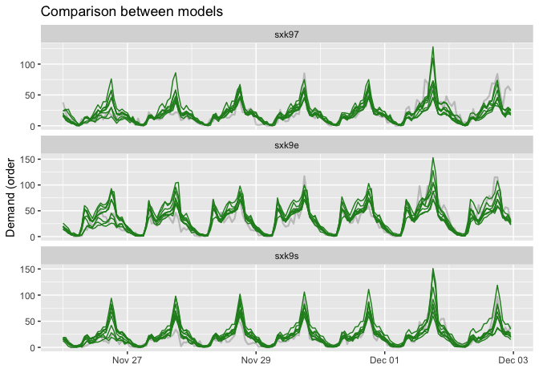

```r
# form data for viz
scotty_test %<>%
  select(src_sub_area, key, actual = test, forecast) %>%
  spread(key, forecast) %>%
  gather(key, value, -src_sub_area) %>%
  unnest(value) %>%
  mutate(demand = rec_revert(demand, rec, src_sub_area))

# Viz
color <- "forestgreen"

ggplot(scotty_test, aes(x = datetime, y = demand)) +
  geom_line(data = scotty_test %>% filter(key == "actual"), aes(y = demand), alpha = 0.2, size = 0.8) +
  geom_line(data = scotty_test %>% filter(key != "actual"), aes(frame = key, col = key)) +
  labs(x = "", y = "Demand (order", title = "Comparison between models", frame="Models") +
  facet_wrap(~ src_sub_area, scale = "free_y", ncol = 1) +
  scale_color_manual(values = c(color, color, color, color, color, color, color, color, color)) +
  theme(legend.position = "none")
```

Now, let’s choose the model that have smallest prediction error for each sub-area.

```r
# select least error
scotty_min_error <- scotty_error %>%
  select(-fitted) %>%
  group_by(src_sub_area) %>%
  filter(error == min(error)) %>%
  ungroup()

# combining train and test data
scotty_full <- scotty_min_error %>%
  mutate(fulldata = map2(train, test, ~ bind_rows(.x, .y))) %>%
  select(src_sub_area, fulldata, everything(), -train, -test)

scotty_full
```

```
## # A tibble: 3 x 7
##   src_sub_area fulldata       data_fun_name data_fun model_name model error
##   <chr>        <list>         <chr>         <list>   <chr>      <lis> <dbl>
## 1 sxk97        <tibble [1,51… msts          <fn>     tbats      <fn>  10.1
## 2 sxk9e        <tibble [1,51… msts          <fn>     tbats      <fn>   7.57
## 3 sxk9s        <tibble [1,51… msts          <fn>     tbats      <fn>   8.28
```

tbats model have least error for each sub-area. then, we combine test and train data to form final model.

Below shown the modelling by using tbats model toward dataset that is already been combined, then crate demand prediction for the next seven days.

```r
#running the model
scottyfull_nest <- scotty_full %>%
  mutate(
    params = map(fulldata, ~ list(x = .x)),
    data = invoke_map(data_fun, params),
    params = map(data, ~ list(x = .x)),
    fitted = invoke_map(model, params)
  ) %>%
  select(-data, -params)

# forecasting
scottyfull_nest <- scottyfull_nest %>%
  mutate(forecast =
           map(fitted, ~ forecast(.x, h = 24 * 7)) %>%
           map2(fulldata, ~ tibble(
             datetime = timetk::tk_make_future_timeseries(.y$datetime, 24 * 7),
             demand = as.vector(.x$mean)
           )))

scottyfull_nest
```

```
## # A tibble: 3 x 9
##   src_sub_area fulldata data_fun_name data_fun model_name model error
##   <chr>        <list>   <chr>         <list>   <chr>      <lis> <dbl>
## 1 sxk97        <tibble… msts          <fn>     tbats      <fn>  10.1
## 2 sxk9e        <tibble… msts          <fn>     tbats      <fn>   7.57
## 3 sxk9s        <tibble… msts          <fn>     tbats      <fn>   8.28
## # … with 2 more variables: fitted <list>, forecast <list>
```

Let’s unnest nested data and create visualization from prediction result.

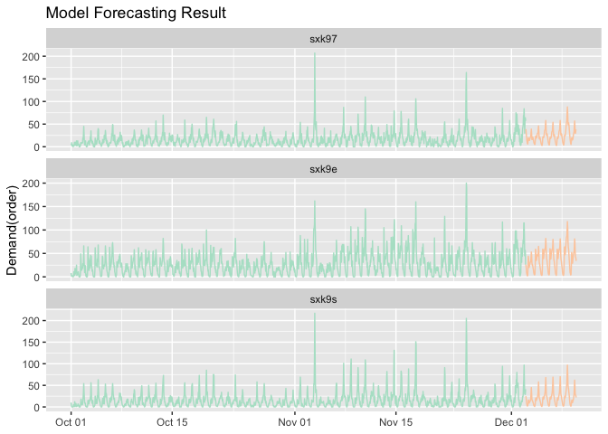

```r
# conceal nest data
scottyfull_unnest <- scottyfull_nest %>%
  select(src_sub_area, actual = fulldata, forecast) %>%
  gather(key, value, -src_sub_area) %>%
  unnest(value) %>%
  mutate(demand = rec_revert(demand, rec, src_sub_area))

# Viz
ggplot(scottyfull_unnest, aes(x = datetime, y = demand, colour = key)) +
  geom_line() +
  labs(y = "Demand(order)", x = NULL, title = "Model Forecasting Result") +
  facet_wrap(~ src_sub_area, scale = "free_y", ncol = 1) +
  scale_color_brewer(palette = "Pastel2") +
  theme(legend.position = "none")
```

The unnest data is shown below.

```r
scottyfull_unnest
```

```
## # A tibble: 5,040 x 4
##    src_sub_area key    datetime            demand
##    <chr>        <chr>  <dttm>               <dbl>
##  1 sxk97        actual 2017-10-01 00:00:00      6
##  2 sxk97        actual 2017-10-01 01:00:00      4
##  3 sxk97        actual 2017-10-01 02:00:00      9
##  4 sxk97        actual 2017-10-01 03:00:00      2
##  5 sxk97        actual 2017-10-01 04:00:00      5
##  6 sxk97        actual 2017-10-01 05:00:00      4
##  7 sxk97        actual 2017-10-01 06:00:00      1
##  8 sxk97        actual 2017-10-01 07:00:00      0
##  9 sxk97        actual 2017-10-01 08:00:00      3
## 10 sxk97        actual 2017-10-01 09:00:00      3
## # … with 5,030 more rows
```

```r
data_test <- scottyfull_unnest %>%
  filter(datetime %within% intest) %>%
  select(src_sub_area, datetime, demand)

data_test
```

```
## # A tibble: 504 x 3
##    src_sub_area datetime            demand
##    <chr>        <dttm>               <dbl>
##  1 sxk97        2017-11-26 00:00:00     38
##  2 sxk97        2017-11-26 01:00:00     21
##  3 sxk97        2017-11-26 02:00:00     10
##  4 sxk97        2017-11-26 03:00:00     10
##  5 sxk97        2017-11-26 04:00:00      5
##  6 sxk97        2017-11-26 05:00:00      2
##  7 sxk97        2017-11-26 06:00:00      0
##  8 sxk97        2017-11-26 07:00:00     11
##  9 sxk97        2017-11-26 08:00:00      4
## 10 sxk97        2017-11-26 09:00:00      4
## # … with 494 more rows
```

# MAE Result for Data Test

```r
mae_test_res <- scotty_error %>%
  group_by(src_sub_area) %>%
  select(src_sub_area, error) %>%
  arrange(error) %>%
  slice(1) %>%
  ungroup()

# Reached MAE < 11 for all sub-area in (your own) test dataset
# We used tbats - the scale for MAE is a little bit different
mae_test_res %<>%
  summarise(src_sub_area = "all sub-area",
            error = mean(error)) %>%
  bind_rows(mae_test_res, .)

mae_test_res
```

```
## # A tibble: 4 x 2
##   src_sub_area error
##   <chr>        <dbl>
## 1 sxk97        10.1
## 2 sxk9e         7.57
## 3 sxk9s         8.28
## 4 all sub-area  8.65
```

# Data Submission

Forecast our data submission using our best model:

```r
submission <- scotty_best_model %>% #use the best model
  mutate(
    forecast =
      map(fitted, ~ forecast(.x, h = 24 * 7)) %>%
      map2(submit_nest$data, ~ tibble( #map into our data submission nest
        datetime = .y$datetime,
        demand = as.vector(.x$mean)
      )),
    key = paste(data_fun_name, model_name, sep = "-")
  )
```

Select only the required columns:

```r
submission <- submission %>%
  select(src_sub_area, forecast) %>%
  unnest(forecast) %>%
  mutate(demand = rec_revert(demand, rec, src_sub_area))

submission
```

```
## # A tibble: 504 x 3
##    src_sub_area datetime            demand
##    <chr>        <dttm>               <dbl>
##  1 sxk97        2017-12-03 00:00:00     18
##  2 sxk97        2017-12-03 01:00:00     15
##  3 sxk97        2017-12-03 02:00:00     11
##  4 sxk97        2017-12-03 03:00:00      7
##  5 sxk97        2017-12-03 04:00:00      5
##  6 sxk97        2017-12-03 05:00:00      3
##  7 sxk97        2017-12-03 06:00:00      2
##  8 sxk97        2017-12-03 07:00:00      6
##  9 sxk97        2017-12-03 08:00:00     12
## 10 sxk97        2017-12-03 09:00:00     12
## # … with 494 more rows
```

Save submission file into csv.

```r
write_csv(submission, "drive-download-20190915T022902Z-001/scotty-ts-auto/faris_scottyts_capstone.csv")
```